# House Pricing Prediction

This challenge is adapted from the well-known '*Zillow's Home Value Prediction*' competition on Kaggle. In particular, given a dataset containing descriptions of homes on the US property market, your task is to make predictions on the selling price of as-yet unlisted properties. Developing a model which accurately fits the available training data while also generalising to unseen data-points is a multi-faceted challenge that involves a mixture of data exploration, pre-processing, model selection, and performance evaluation.

**IMPORTANT**: please refer to the AML course guidelines concerning grading rules. Pay especially attention to the **presentation quality** item, which boils down to: don't dump a zillion of lines of code and plots in this notebook. Produce a concise summary of your findings: this notebook can exist in two versions, a "scratch" version that you will use to work and debug, a "presentation" version that you will submit. The "presentation" notebook should go to the point, and convay the main findings of your work.

## Overview

Beyond simply producing a well-performing model for making predictions, in this challenge we would like you to start developing your skills as a machine learning scientist. In this regard, your notebook should be structured in such a way as to explore the following tasks that are expected to be carried out whenever undertaking such a project. The description below each aspect should serve as a guide for your work, but you are strongly encouraged to also explore alternative options and directions. Thinking outside the box will always be rewarded in these challenges.

### 1. Data preparation:

*Data exploration*: The first broad component of your work should enable you to familiarise yourselves with the given data, an outline of which is given at the end of this challenge specification. Among others, you can work on:

- Data cleaning, e.g. treatment of categorial variables;
- Data visualisation; Computing descriptive statistics, e.g. correlation.

*Data Pre-processing*: The previous step should give you a better understanding of which pre-processing is required for the data. This may include:

- Normalising and standardising the given data;
- Removing outliers;
- Carrying out feature selection, possibly using metrics derived from information theory;
- Handling missing information in the dataset;
- Augmenting the dataset with external information;
- Combining existing features.

### 2. Model selection

An important part of the work involves the selection of a model that can successfully handle the given data and yield sensible predictions. Instead of focusing exclusively on your final chosen model, it is also important to share your thought process in this notebook by additionally describing alternative candidate models. There is a wealth of models to choose from, such as decision trees, random forests, (Bayesian) neural networks, Gaussian processes, LASSO regression, and so on.

Irrespective of your choice, it is highly likely that your model will have one or more parameters that require tuning. There are several techniques for carrying out such a procedure, such as cross-validation.

### 3. Performance Evaluation

The evaluation method for this challenge is the root mean squared error between the logarithm of the predicted value and the logarithm of the observed sales price. Taking logs ensures that errors in predicting expensive houses and cheap houses will have a similar impact on the overall result.

## Dataset Description

#### Files

You will be working on two data files, which will be available in `/mnt/datasets/house/`:

- train.csv - The training dataset;
- test.csv - The test dataset;
- data_description.txt - Full description of each column.

#### Attributes

A brief outline of the available attributes is given below:

- *SalePrice*: The property's sale price in dollars. This is the target variable that your model is intended to predict;
- *MSSubClass*: The building class;
- *MSZoning*: The general zoning classification;
- *LotFrontage*: Linear feet of street connected to property;
- *LotArea*: Lot size in square feet;
- *Street*: Type of road access;
- *Alley*: Type of alley access;
- *LotShape*: General shape of property;
- *LandContour*: Flatness of the property;
- *Utilities*: Type of utilities available;
- *LotConfig*: Lot configuration;
- *LandSlope*: Slope of property;
- *Neighborhood*: Physical locations within Ames city limits;
- *Condition1*: Proximity to main road or railroad;
- *Condition2*: Proximity to main road or railroad (if a second is present);
- *BldgType*: Type of dwelling;
- *HouseStyle*: Style of dwelling;
- *OverallQual*: Overall material and finish quality;
- *OverallCond*: Overall condition rating;
- *YearBuilt*: Original construction date;
- *YearRemodAdd*: Remodel date;
- *RoofStyle*: Type of roof;
- *RoofMatl*: Roof material;
- *Exterior1st*: Exterior covering on house;
- *Exterior2nd*: Exterior covering on house (if more than one material);
- *MasVnrType*: Masonry veneer type;
- *MasVnrArea*: Masonry veneer area in square feet;
- *ExterQualv*: Exterior material quality;
- *ExterCond*: Present condition of the material on the exterior;
- *Foundation*: Type of foundation;
- *BsmtQual*: Height of the basement;
- *BsmtCond*: General condition of the basement;
- *BsmtExposure*: Walkout or garden level basement walls;
- *BsmtFinType1*: Quality of basement finished area;
- *BsmtFinSF1*: Type 1 finished square feet;
- *BsmtFinType2*: Quality of second finished area (if present);
- *BsmtFinSF2*: Type 2 finished square feet;
- *BsmtUnfSF*: Unfinished square feet of basement area;
- *TotalBsmtSF*: Total square feet of basement area;
- *Heating*: Type of heating;
- *HeatingQC*: Heating quality and condition;
- *CentralAir*: Central air conditioning;
- *Electrical*: Electrical system;
- *1stFlrSF*: First Floor square feet;
- *2ndFlrSF*: Second floor square feet;
- *LowQualFinSF*: Low quality finished square feet (all floors);
- *GrLivArea*: Above grade (ground) living area square feet;
- *BsmtFullBath*: Basement full bathrooms;
- *BsmtHalfBath*: Basement half bathrooms;
- *FullBath*: Full bathrooms above grade;
- *HalfBath*: Half baths above grade;
- *Bedroom*: Number of bedrooms above basement level;
- *Kitchen*: Number of kitchens;
- *KitchenQual*: Kitchen quality;
- *TotRmsAbvGrd*: Total rooms above grade (does not include bathrooms);
- *Functional*: Home functionality rating;
- *Fireplaces*: Number of fireplaces;
- *FireplaceQu*: Fireplace quality;
- *GarageType*: Garage location;
- *GarageYrBlt*: Year garage was built;
- *GarageFinish*: Interior finish of the garage;
- *GarageCars*: Size of garage in car capacity;
- *GarageArea*: Size of garage in square feet;
- *GarageQual*: Garage quality;
- *GarageCond*: Garage condition;
- *PavedDrive*: Paved driveway;
- *WoodDeckSF*: Wood deck area in square feet;
- *OpenPorchSF*: Open porch area in square feet;
- *EnclosedPorch*: Enclosed porch area in square feet;
- *3SsnPorch*: Three season porch area in square feet;
- *ScreenPorch*: Screen porch area in square feet;
- *PoolArea*: Pool area in square feet;
- *PoolQC*: Pool quality;
- *Fence*: Fence quality;
- *MiscFeature*: Miscellaneous feature not covered in other categories;
- *MiscVal*: Value (in dollars) of miscellaneous feature;
- *MoSold*: Month sold;
- *YrSold*: Year sold;
- *SaleType*: Type of sale;
- *SaleCondition*: Condition of sale.

# Group 20 : Solution

## by Clément Bernard,Brugeres Maxence and Guyard Martin

```python
# Importations
%matplotlib inline
import numpy as np
import matplotlib.pyplot as plt
import pandas as pd
import seaborn as sn
from sklearn.preprocessing import StandardScaler
from sklearn.model_selection import train_test_split
from sklearn.model_selection import cross_validate, GridSearchCV
from sklearn.metrics import mean_squared_error
from sklearn.feature_selection import mutual_info_regression, mutual_info_classif
from sklearn.feature_selection import SelectKBest
from sklearn.preprocessing import LabelEncoder
from sklearn.preprocessing import OrdinalEncoder


SEED = 77
```

### 1. Data preparation

```python
dataset = pd.read_csv('train.csv')
test = pd.read_csv('test.csv')
```

```python
dataset.columns
```

```
Index(['Id', 'MSSubClass', 'MSZoning', 'LotFrontage', 'LotArea', 'Street',
       'Alley', 'LotShape', 'LandContour', 'Utilities', 'LotConfig',
       'LandSlope', 'Neighborhood', 'Condition1', 'Condition2', 'BldgType',
       'HouseStyle', 'OverallQual', 'OverallCond', 'YearBuilt', 'YearRemodAdd',
       'RoofStyle', 'RoofMatl', 'Exterior1st', 'Exterior2nd', 'MasVnrType',
       'MasVnrArea', 'ExterQual', 'ExterCond', 'Foundation', 'BsmtQual',
       'BsmtCond', 'BsmtExposure', 'BsmtFinType1', 'BsmtFinSF1',
       'BsmtFinType2', 'BsmtFinSF2', 'BsmtUnfSF', 'TotalBsmtSF', 'Heating',
       'HeatingQC', 'CentralAir', 'Electrical', '1stFlrSF', '2ndFlrSF',
       'LowQualFinSF', 'GrLivArea', 'BsmtFullBath', 'BsmtHalfBath', 'FullBath',
       'HalfBath', 'BedroomAbvGr', 'KitchenAbvGr', 'KitchenQual',
       'TotRmsAbvGrd', 'Functional', 'Fireplaces', 'FireplaceQu', 'GarageType',
       'GarageYrBlt', 'GarageFinish', 'GarageCars', 'GarageArea', 'GarageQual',
       'GarageCond', 'PavedDrive', 'WoodDeckSF', 'OpenPorchSF',
       'EnclosedPorch', '3SsnPorch', 'ScreenPorch', 'PoolArea', 'PoolQC',
       'Fence', 'MiscFeature', 'MiscVal', 'MoSold', 'YrSold', 'SaleType',
       'SaleCondition', 'SalePrice'],
      dtype='object')
```

```python
dataset.shape
```

```
(1200, 81)
```

#### 1.1 Data cleaning

First see the **missing values** for each feature

```python
# Print the features that have high ratio of NaN values
(dataset.isnull().sum()/dataset.shape[0]*100).sort_values(ascending = False).head(20)
```

```
PoolQC          99.666667
MiscFeature     96.083333
Alley           93.750000
Fence           81.083333
FireplaceQu     47.000000
LotFrontage     17.500000
GarageType       5.583333
GarageCond       5.583333
GarageYrBlt      5.583333
GarageFinish     5.583333
GarageQual       5.583333
BsmtExposure     2.750000
BsmtFinType2     2.750000
BsmtFinType1     2.666667
BsmtCond         2.666667
BsmtQual         2.666667
MasVnrArea       0.500000
MasVnrType       0.500000
Exterior2nd      0.000000
Exterior1st      0.000000
dtype: float64
```

We decide to remove the features that have more than 30 % missing values. Indeed, this choice is arbitrary and aims to have data that is correct and not fulfilled by false ones.

```python
# Finds the columns that have more than 30% NaN values
drop_columns = np.where(dataset.isnull().sum() / dataset.shape[0]*100 > 30)[0]

# Prints these columns
for x in drop_columns :
    print('Column dropped : {}'.format(dataset.columns.values[x]))
```

```
Column dropped : Alley
Column dropped : FireplaceQu
Column dropped : PoolQC
Column dropped : Fence
Column dropped : MiscFeature
```

```python
# Drops these features
dataset.drop(dataset.columns[drop_columns], axis = 1, inplace= True)
test.drop(test.columns[drop_columns], axis = 1, inplace= True)
print('Size of dataset without those features : {}'.format(dataset.shape))
```

```
Size of dataset without those features : (1200, 76)
```

The next step is to remove the less important features

#### 1.2 First feature selection

##### 1.2.1 Categorical variables

```python
# Let's try to see which categorical features (non numeric) are relevant
# first get the features and their mutual information with the price

mir = lambda x,y :  mutual_info_regression(x,y, random_state = SEED)

non_Categorical_features = dataset.corr().drop('SalePrice').SalePrice.index
non_Categorical_features_index = [dataset.columns.get_loc(non_Categorical_features[i]) for i in range(non_Categorical_features.size)]
categorical_dataset = dataset.drop(dataset.columns[non_Categorical_features_index], axis = 1, inplace= False)
categorical_dataset_noNull = categorical_dataset.dropna()

oe = OrdinalEncoder()
oe.fit(categorical_dataset_noNull.drop('SalePrice', axis = 1))
X_train_enc = oe.transform(categorical_dataset_noNull.drop('SalePrice', axis = 1))
categorical_Features = categorical_dataset_noNull.drop('SalePrice', axis = 1).columns

fs = SelectKBest(score_func=mir, k='all')
fs.fit(X_train_enc, categorical_dataset_noNull.SalePrice)

mutual_Info_Non_Cat_Features = pd.Series(fs.scores_,index=categorical_Features).sort_values(ascending = False)
```

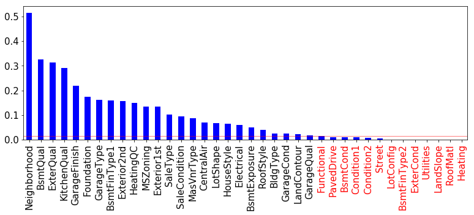

```python
# Then plot the result with respect to a threshold

categorical_threshold=0.015

n_drop_columns = len(mutual_Info_Non_Cat_Features[mutual_Info_Non_Cat_Features<categorical_threshold].index)
plt.axhline(categorical_threshold, color='r', linewidth= 0.5)
mutual_Info_Non_Cat_Features.plot(kind='bar', figsize= (13,4), fontsize=15,color='b')
for label in plt.gca().get_xticklabels()[-n_drop_columns:]:
    label.set_color('red')
```

We simplify the data by dropping the features with a mutual information less than 0.015. Indeed, this is an arbitrary choice.

```python
## We simplify the model dropping the features with a mutual information less than 0.015
drop_columns = mutual_Info_Non_Cat_Features[mutual_Info_Non_Cat_Features<categorical_threshold].index
```

```python
dataset.drop(drop_columns, axis= 1 , inplace= True)
test.drop(drop_columns, axis= 1 , inplace= True)
```

```python
print(len(drop_columns), 'columns dropped:')
print('\n'.join(list(drop_columns)))
```

```
13 columns dropped:
Functional
PavedDrive
BsmtCond
Condition1
Condition2
Street
LotConfig
BsmtFinType2
ExterCond
Utilities
LandSlope
RoofMatl
Heating
```

##### 1.2.2 Continuous variables

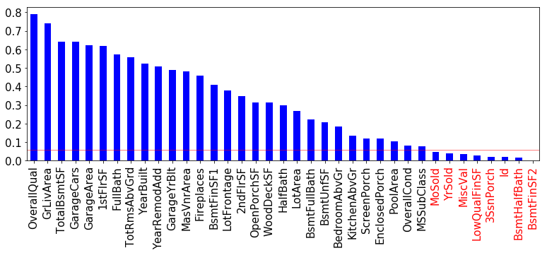

```python
# For the numerical features, let's check the correlation with the price
correlation = dataset.corr().SalePrice.abs().sort_values(ascending = False).drop('SalePrice')

# Get useless features with respect to a threshold

numerical_threshold = 0.06

def get_features_useless(correlation , threshold) :
    # Get the features that are less correlated than the threshold
    high_features = correlation.abs()
    indexes = ((high_features<threshold)*1)[((high_features<threshold)*1) >=1 ].index
    return indexes

n_features_useless = len(get_features_useless(correlation, numerical_threshold))

correlation.plot(kind='bar', figsize= (13,4), fontsize=15,color='b')
plt.axhline(numerical_threshold, color='r', linewidth= 0.5)
for label in plt.gca().get_xticklabels()[-n_features_useless:]:
    label.set_color('red')
```

```python
# We simplify the model dropping the features with a correlation less than 0.06
features_useless = get_features_useless(correlation, numerical_threshold)
```

```python
# Drop these features
dataset.drop(features_useless, axis= 1 , inplace= True)
test.drop(features_useless, axis= 1 , inplace= True)
```

```python
print(len(features_useless), 'columns dropped:')
print('\n'.join(list(features_useless)))
```

```
8 columns dropped:
MoSold
YrSold
MiscVal
LowQualFinSF
3SsnPorch
Id
BsmtHalfBath
BsmtFinSF2
```

Let's plot the correlation between features. Highly correlated features should be dropped.

```python
corr = dataset.corr()

# We filter for correlation > 0.8 (considered highly correlated)
corr = corr[corr>0.8]
coordinates = np.argwhere(corr.notnull().values).tolist()
l = []
for x in coordinates:
    if (x[0] != x[1]) and ((x[1], x[0]) not in l):
        l.append((x[0], x[1]))
for i, c in l:
    print('{:<25} {:<25} {:<25}'.format(corr.index[i], corr.columns[c], round(corr.iloc[i][c],3)))
```

```
YearBuilt                 GarageYrBlt               0.839
TotalBsmtSF               1stFlrSF                  0.807
GrLivArea                 TotRmsAbvGrd              0.83
GarageCars                GarageArea                0.885
```

We drop one set of features to avoid too much correlation between features. For instance YearBuilt and GarageYearBuilt are not both necessary, only one should be kept. It tells the same information.

```python
features_redondant = ['GarageYrBlt','1stFlrSF','TotRmsAbvGrd','GarageArea']
dataset.drop(features_redondant, axis=1, inplace=True)
test.drop(features_redondant, axis=1, inplace=True)
```

#### 1.3 NaN values

Now we'll handle **NaN** values and standardize the values

First, let's check what are they

```python
# Get the columns that have NaN values
indexes_nan = np.where(dataset.isnull().sum().values !=0 )[0]
indexes_nan_test = np.where(test.isnull().sum().values !=0 )[0]
```

```python
# Print the feature with NaN values and the values it have
for column in indexes_nan :
    print('Feature : {} and got values : {}'.format(dataset.columns[column],\
                                                   dataset[dataset.columns[column]].unique()))

    print('')
```

[output not shown]

[output cut: 11 more lines]

```
 3.370e+02 1.490e+02 1.430e+02 5.100e+01]

Feature : BsmtQual and got values : ['Gd' 'TA' 'Ex' nan 'Fa']

Feature : BsmtExposure and got values : ['No' 'Gd' 'Mn' 'Av' nan]

Feature : BsmtFinType1 and got values : ['GLQ' 'ALQ' 'Unf' 'Rec' 'BLQ' nan 'LwQ']

Feature : GarageType and got values : ['Attchd' 'Detchd' 'BuiltIn' 'CarPort' nan 'Basment' '2Types']

Feature : GarageFinish and got values : ['RFn' 'Unf' 'Fin' nan]

Feature : GarageQual and got values : ['TA' 'Fa' 'Gd' nan 'Ex' 'Po']

Feature : GarageCond and got values : ['TA' 'Fa' nan 'Gd' 'Po' 'Ex']
```

For the features that have numerical values, we can fulfill the NaN values by the mean for instance. This is an arbitrary decision. We could have replaced by the previous value or by doing regression knowing the other features. Here we took the average.

```python
# Fill the features with numerical values by the mean.
num_features_nan_types = dataset[dataset.columns[indexes_nan]].dtypes!=object
num_features_nan = dataset[dataset.columns[indexes_nan]].columns[num_features_nan_types].tolist()

num_features_nan_types_test = test[test.columns[indexes_nan_test]].dtypes!=object
num_features_nan_test = test[test.columns[indexes_nan_test]].columns[num_features_nan_types_test].tolist()



for column in num_features_nan :
    # Compute the mean
    feature_mean = dataset[column].mean()

    # Fulfill the NaN values by the mean
    dataset[column].fillna(feature_mean , inplace=True)
    print('Column for training : {} has been filled'.format(column))


for column in num_features_nan_test :
    feature_mean_test = test[column].mean()
    test[column].fillna(feature_mean_test , inplace=True)
    print('Column for testing : {} has been filled'.format(column))
```

```
Column for training : LotFrontage has been filled
Column for training : MasVnrArea has been filled
Column for testing : LotFrontage has been filled
Column for testing : MasVnrArea has been filled
```

Let's drop the outliers before standartize the numerical values

```
Feature : MSSubClass
```

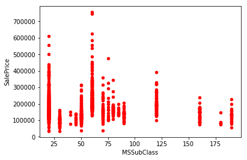

```
Feature : LotFrontage
```

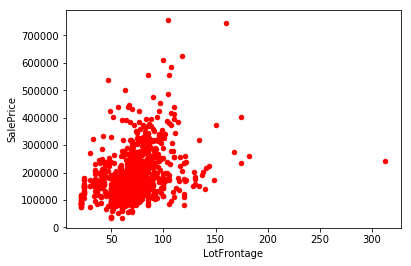

```
Feature : LotArea
```

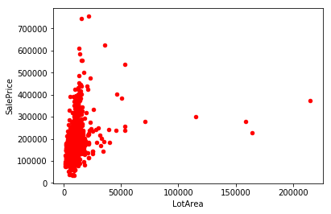

```
Feature : YearBuilt
```

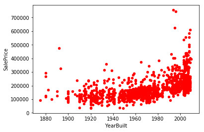

```
Feature : YearRemodAdd
```

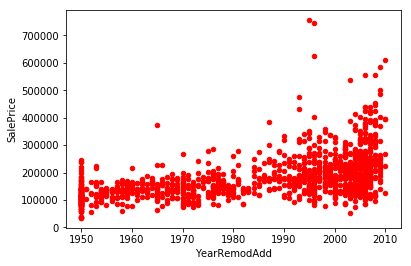

```
Feature : MasVnrArea
```

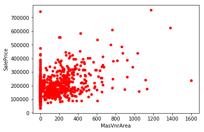

```
Feature : BsmtFinSF1
```

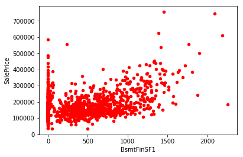

```
Feature : BsmtUnfSF
```

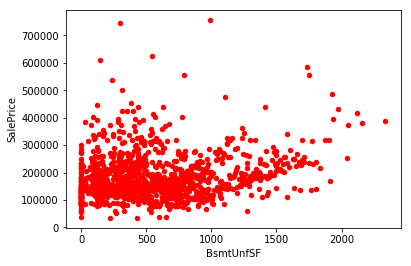

```
Feature : TotalBsmtSF
```

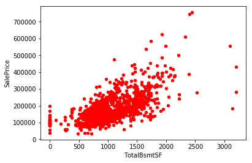

```
Feature : 2ndFlrSF
```

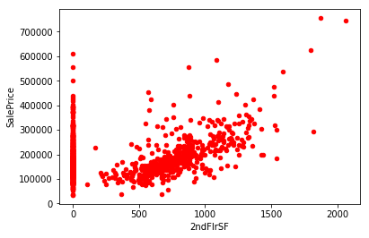

```
Feature : GrLivArea
```

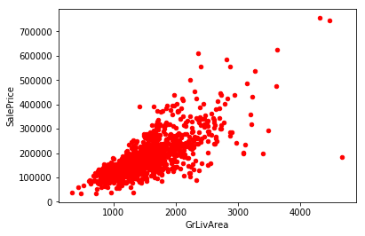

```
Feature : WoodDeckSF
```

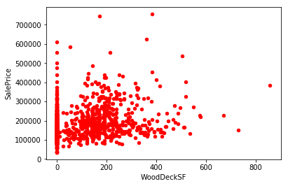

```
Feature : OpenPorchSF
```

[3 more figures not shown]

```python
# Plot the Saleprice depending on the float features
numerical_features_types = dataset.dtypes!=object
numerical_features = dataset.columns[numerical_features_types].tolist()
for feature in numerical_features :
    # Plot the numerical features with more than 10 different values (not the K encoded ones)
    if (len(dataset[feature].unique()) > 10 and feature != 'SalePrice') :
        print('Feature : {}'.format(feature))

        dataset.plot(kind = 'scatter', x=feature,y='SalePrice' , color = 'r')
        plt.show()
```

```python
# Drop the outliers by hand
def drop_outliers(dic) :
    for value in dic :
        dataset.drop(dataset[dataset[value]>dic[value]]. index, axis=0, inplace=True)
        test.drop(test[test[value]>dic[value]]. index, axis=0, inplace=True)
```

```python
features_outliers = {'LotFrontage':200,'LotArea':60000,'MasVnrArea':1200,\
                    'GrLivArea':4000,'EnclosedPorch':400,'WoodDeckSF':600}
drop_outliers(features_outliers)
```

```python
num_features_poly_types = dataset.drop('SalePrice', axis=1).dtypes!=object
num_features_poly = dataset.drop('SalePrice', axis=1).columns[num_features_poly_types]
```

```python
for col in num_features_poly[:-1]:
    string = 'SQUARE ' + col
    dataset[string] = dataset[col]**2
    test[string] = test[col]**2
dataset['bias'] = 1
test['bias']=1
```

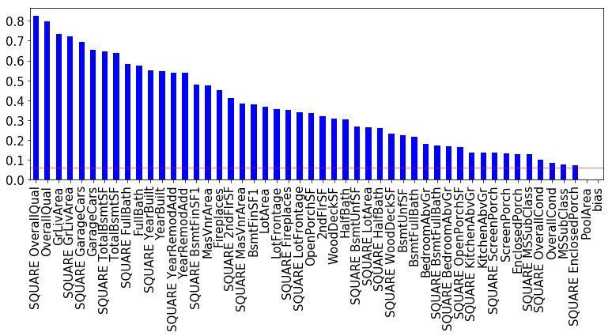

```python
#Check the new correlation
correlation = dataset.corr().SalePrice.abs().sort_values(ascending = False).drop('SalePrice')

def get_features_useless(correlation , threshold) :
    # Get the features that are less correlated than the threshold
    high_features = correlation.abs()
    indexes = ((high_features<threshold)*1)[((high_features<threshold)*1) >=1 ].index
    return indexes

correlation.plot(kind='bar', figsize= (13,4), fontsize=15,color='b')
plt.axhline(numerical_threshold, color='r', linewidth= 0.5)
```

Then let's standardize the numerical values since they are now complete

```python
# Then standardize before touching to categorical feature
from sklearn.preprocessing import StandardScaler


# Get in memory the features that have non-string values
numerical_features_types = dataset.drop('SalePrice', axis=1).dtypes!=object
numerical_features = dataset.drop('SalePrice', axis=1).columns[numerical_features_types].tolist()

# Then fit the scaler
scaled_data = dataset[numerical_features]
scaled_data_test = test[numerical_features]
scaler = StandardScaler().fit(scaled_data)

# Finally change the values in the dataset
scaled_data = scaler.transform(scaled_data)
scaled_data_test = scaler.transform(scaled_data_test)
dataset[numerical_features] = scaler.transform(scaled_data)
test[numerical_features] = scaler.transform(scaled_data_test)
```

Now, handle NaN in categorical features

To deal with NaN values, there are different methods. We can either fill with random values or with mean. Another method would be to just delete the row (but we'll miss too much data here). Then, we can also replace it with an 'unknown' value. And finally we can predict the NaN values thanks to the other data we have.  
We'll try here with **replacing by a None value** , which will basically add a feature when we'll do K-encoding.

```python
string_features_nan_types = dataset.dtypes==object
string_features_nan = dataset.columns[string_features_nan_types].tolist()

string_features_nan_types_test = test.dtypes==object
string_features_nan_test = test.columns[string_features_nan_types_test].tolist()
```

```python
# Replace NaN values by a None category
for feature in string_features_nan :
    dataset[feature].fillna('None', inplace = True)
for feature in string_features_nan_test :
    test[feature].fillna('None', inplace = True)
```

We then want to vectorize our data. We need to convert all the strings into numerical values.  
We have two choices : either **convert strings to integers** (like 'bad' becomes 0, 'good' becomes 1, etc) **this is ordinal encoding (and it is relevant if the feature represent a hierarchy)** or to do **K-encoding** by creating a new binary feature for each value of a given feature.  
Let's see which feature is a string.

```python
# Get the boolean list of contents that are object and not integers
categorical_features_types = dataset.dtypes==object

# Get the features that are strings
categorical_columns = dataset.columns[categorical_features_types].tolist()
print('Categorical features:\n {}'.format('\n '.join(list(categorical_columns))))
print('Number of features : {}'.format(len(categorical_columns)))
```

```
Categorical features:
 MSZoning
 LotShape
 LandContour
 Neighborhood
 BldgType
 HouseStyle
 RoofStyle
 Exterior1st
 Exterior2nd
 MasVnrType
 ExterQual
 Foundation
 BsmtQual
 BsmtExposure
 BsmtFinType1
 HeatingQC
 CentralAir
 Electrical
 KitchenQual
 GarageType
 GarageFinish
 GarageQual
 GarageCond
 SaleType
 SaleCondition
Number of features : 25
```

We then need to know which feature has a natural order or not (and then it will lead to use K encoding).  
After an analysis on the data, whenever there is a quality that comes, there is an order and therefore convert it into integers makes sense. Otherwise, we'll use K encoding.  
Here is the list of features that need **conversion: ordinal encoding** (where there is an order) :

- **ExterQual**
- **BsmtQual**
- **BsmtExposure**
- **BsmtFinType1**
- **HeatingQC**
- **CentralAir**
- **KitchenQual**
- **GarageFinish**
- **GarageQual**
- **GarageCond**

Here is the list of contents that require K encoding :

- **MSZoning**
- **LotShape**
- **LandContour**
- **Neighborhood**
- **BldgType**
- **HouseStyle**
- **RoofStyle**
- **Exterior1st**
- **Exterior2nd**
- **MasVnrType**
- **Foundation**
- **Electrical**
- **GarageType**
- **SaleCondition**
- **SaleType**

```python
features_to_convert = ['ExterQual','BsmtQual',\
                  'BsmtExposure', 'BsmtFinType1','HeatingQC','CentralAir',\
                       'KitchenQual','GarageFinish','GarageQual','GarageCond']
```

```python
features_to_encode = ['MSZoning','LotShape','LandContour','Neighborhood',\
                     'BldgType','HouseStyle','RoofStyle','Exterior1st','Exterior2nd',\
                      'MasVnrType','Foundation','Electrical','GarageType',\
                      'SaleCondition','SaleType']
```

```python
# Print the disctinct values and create the list of dictionnaries
dic = []
for feature in features_to_convert :

    unique_values = np.unique( np.concatenate( (dataset[feature].unique() , test[feature].unique())))
    print(str(feature) + ' : {}'.format(unique_values) )
```

```
ExterQual : ['Ex' 'Fa' 'Gd' 'TA']
BsmtQual : ['Ex' 'Fa' 'Gd' 'None' 'TA']
BsmtExposure : ['Av' 'Gd' 'Mn' 'No' 'None']
BsmtFinType1 : ['ALQ' 'BLQ' 'GLQ' 'LwQ' 'None' 'Rec' 'Unf']
HeatingQC : ['Ex' 'Fa' 'Gd' 'Po' 'TA']
CentralAir : ['N' 'Y']
KitchenQual : ['Ex' 'Fa' 'Gd' 'TA']
GarageFinish : ['Fin' 'None' 'RFn' 'Unf']
GarageQual : ['Ex' 'Fa' 'Gd' 'None' 'Po' 'TA']
GarageCond : ['Ex' 'Fa' 'Gd' 'None' 'Po' 'TA']
```

```python
# We'll use a dictionary to preserve the order
dic_ex = {'Po':0, 'Fa':1, 'None':2,'TA':3,'Gd':4,'Ex':5}
dic_rate = {'GLQ' : 6,'ALQ':5,'BLQ': 4, 'None': 3, 'Rec': 2, 'LwQ': 1,'Unf' :0 }
dic_exposure = {'No':0,'Mn':1,'None':2,'Av':3, 'Gd':5}
dic_garage = {'Unf':0, 'None':1,'RFn':2, 'Fin':3}
dic_bin = {'N':0,'Y':1}

# Reference dictionary
total_dic = [dic_ex,dic_rate,dic_exposure,dic_garage,dic_bin]
```

```python
# Then replace it in the dataset

dataset[features_to_convert[0]].replace(total_dic[0], inplace=True)
dataset[features_to_convert[1]].replace(total_dic[0], inplace=True)
dataset[features_to_convert[2]].replace(total_dic[2], inplace=True)
dataset[features_to_convert[3]].replace(total_dic[1], inplace=True)
dataset[features_to_convert[4]].replace(total_dic[0], inplace=True)
dataset[features_to_convert[5]].replace(total_dic[-1], inplace=True)
dataset[features_to_convert[6]].replace(total_dic[0], inplace=True)
dataset[features_to_convert[7]].replace(total_dic[-2], inplace=True)
dataset[features_to_convert[8]].replace(total_dic[0], inplace=True)
dataset[features_to_convert[9]].replace(total_dic[0], inplace=True)


test[features_to_convert[0]].replace(total_dic[0], inplace=True)
test[features_to_convert[1]].replace(total_dic[0], inplace=True)
test[features_to_convert[2]].replace(total_dic[2], inplace=True)
test[features_to_convert[3]].replace(total_dic[1], inplace=True)
test[features_to_convert[4]].replace(total_dic[0], inplace=True)
test[features_to_convert[5]].replace(total_dic[-1], inplace=True)
test[features_to_convert[6]].replace(total_dic[0], inplace=True)
test[features_to_convert[7]].replace(total_dic[-2], inplace=True)
test[features_to_convert[8]].replace(total_dic[0], inplace=True)
test[features_to_convert[9]].replace(total_dic[0], inplace=True)
```

```python
# Verify that it worked
dataset[features_to_convert].head(5)
```

|  | ExterQual | BsmtQual | BsmtExposure | BsmtFinType1 | HeatingQC | CentralAir | KitchenQual | GarageFinish | GarageQual | GarageCond |
| --- | --- | --- | --- | --- | --- | --- | --- | --- | --- | --- |
| 0 | 4 | 4 | 0 | 6 | 5 | 1 | 4 | 2 | 3 | 3 |
| 1 | 3 | 4 | 5 | 5 | 5 | 1 | 3 | 2 | 3 | 3 |
| 2 | 4 | 4 | 1 | 6 | 5 | 1 | 4 | 2 | 3 | 3 |
| 3 | 3 | 3 | 0 | 5 | 4 | 1 | 4 | 0 | 3 | 3 |
| 4 | 4 | 4 | 3 | 6 | 5 | 1 | 4 | 2 | 3 | 3 |

Now let's do the K encoding. We first of all convert the values into integers before creating a new feature for each value that a feature has.

```python
# Loop over the features and K encode it
new_dataset = pd.DataFrame()
new_test = pd.DataFrame()
# Encode the features
for feature in features_to_encode :

    # The new columns K encoded
    new_columns = pd.get_dummies(dataset[feature], prefix_sep='_', drop_first=False, prefix = feature)

    new_columns_test = pd.get_dummies(test[feature], prefix_sep='_', drop_first=False, prefix = feature)

    # Make sure there is a good alignment between test and training sets
    new_columns, new_columns_test = new_columns.align(new_columns_test,join = 'left',\
                                                      axis=1, fill_value=0)

    # Concatenation and drop the original feature
    new_dataset = pd.concat([new_dataset, new_columns], ignore_index=False, axis = 1)
    dataset.drop(feature, inplace=True,axis=1)


    new_test = pd.concat([new_test, new_columns_test], ignore_index=False, axis = 1)
    test.drop(feature, inplace=True,axis=1)





# Add it to the dataset

dataset = pd.concat([dataset, new_dataset], axis=1)
test = pd.concat([test, new_test], axis=1)
```

#### 1.4 Split into inputs and labels

```python
# Split the data into target and inputs

y_train = dataset.SalePrice.values
X_train = dataset.drop(['SalePrice'], axis = 1).values

y_test = test.SalePrice.values
X_test = test.drop(['SalePrice'], axis = 1).values
```

### 2. Model selection

```python
def log_rmse(y,y_pred) :
    mse = mean_squared_error(  np.log(y*[y>0] + [y<=0]*1), np.log(y_pred*[y_pred>0] + [y_pred<=0]*1)  )
    return np.sqrt(mse)
```

```python
def tuned_acc(y,y_pred) :
    N = len(y)
    r=0
    for i in range(0,N-1):
       r = r + abs(y[i]-y_pred[i])/y[i]
    return 1-r/N
```

Linear regression

```python
def plot_scores(clf,name) :


    clf_score = cross_validate(clf, X_train, y_train, scoring={'log_rmse': make_scorer(log_rmse), \
                                                           'tuned_acc': make_scorer(tuned_acc),                                                }, cv=5)

    y_predict_clf = clf.fit(X_train, y_train).predict(X_train)



    data = {'Training set' : [log_rmse(y_predict_clf,y_train), tuned_acc(y_predict_clf,y_train)],\
           'Validation set': [clf_score['test_log_rmse'].mean(),clf_score['test_tuned_acc'].mean()]}

    df = pd.DataFrame(data, columns=['Training set','Validation set'], index=['Log RMSE','Tuned Acc'])
    print('Model used : {}'.format(name))
    return df
```

```python
from sklearn.linear_model import LinearRegression
from sklearn.metrics.scorer import make_scorer
from sklearn.metrics import r2_score

reg = LinearRegression()
reg_score = cross_validate(reg, X_train, y_train, scoring={'log_rmse': make_scorer(log_rmse), \
                                                           'tuned_acc': make_scorer(tuned_acc),\
                                                          'r2_score':make_scorer(r2_score)}, cv=5)
reg = LinearRegression().fit(X_train, y_train)
```

```python
plot_scores(reg,'Linear Regression')
```

```
Model used : Linear Regression
```

|  | Training set | Validation set |
| --- | --- | --- |
| Log RMSE | 0.110081 | 0.156911 |
| Tuned Acc | 0.924130 | 0.898452 |

Random forest

```python
from sklearn.model_selection import learning_curve
```

```python
from sklearn.ensemble import RandomForestRegressor
from sklearn.model_selection import ShuffleSplit

def plot_learning_curve(estimator, X, y, scoring=make_scorer(log_rmse)):
    fig, axes = plt.subplots(figsize=(8, 8))
    cv = ShuffleSplit(n_splits=5, random_state=SEED)

    axes.set_xlabel("Training examples")
    axes.set_ylabel("Score log rmse")

    train_sizes, train_scores, test_scores = learning_curve( \
        estimator, X, y,  cv=cv, scoring=scoring, random_state=SEED)
    train_scores_mean = np.mean(train_scores, axis=1)
    train_scores_std = np.std(train_scores, axis=1)
    test_scores_mean = np.mean(test_scores, axis=1)
    test_scores_std = np.std(test_scores, axis=1)

    # Plot learning curve
    axes.grid()
    axes.plot(train_sizes, train_scores_mean, 'o-', color="r",
                 label="Training score")
    axes.plot(train_sizes, test_scores_mean, 'o-', color="g",
                 label="Cross-validation score")
    axes.legend(loc="best")

    return plt

def features_importances(forest, columns, k=5):
    # Get the top k features of the forest (best entropy increase feature)
    importances = forest.feature_importances_
    std = np.std([tree.feature_importances_ for tree in forest.estimators_],
             axis=0)
    indices = np.argsort(importances)[::-1]

    # Print the feature ranking
    print("Feature ranking:")

    for f in range(k):
        print("%d. feature %s (%f)" % (f + 1, columns[indices[f]], importances[indices[f]]))

    # Plot the feature importances of the forest
    plt.figure(figsize=(10,4))

    plt.gca().spines['top'].set_visible(False)
    plt.gca().spines['right'].set_visible(False)

    plt.title("Feature importances")
    plt.bar(range(k), importances[indices][:k],
       color="#65baf8", yerr=std[indices][:k], align="center")
    plt.xticks(range(k), [columns[i] for i in indices[:k]])
    plt.xlim([-1, k])
    plt.show()
```

```
<module 'matplotlib.pyplot' from '/usr/local/lib/python3.5/dist-packages/matplotlib/pyplot.py'>
```

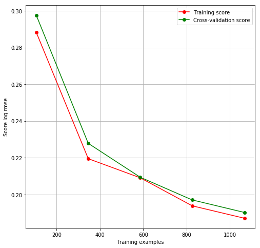

```python
plot_learning_curve(RandomForestRegressor(n_estimators=40,
                                          max_depth=50,
                                          max_features='log2',
                                          min_samples_leaf=20,
                                          min_samples_split=8,
                                         ), X_train, y_train)
```

```python
param_rfr = [{'n_estimators': [10, 50,100,150],
              'max_depth': [5, 10, 20, 40] ,
              'random_state': [SEED]}]

grid_rfr = GridSearchCV(RandomForestRegressor(), param_grid=param_rfr, scoring=make_scorer(log_rmse), cv=5)
grid_rfr.fit(X_train, y_train)
```

```
GridSearchCV(cv=5, error_score=nan,
             estimator=RandomForestRegressor(bootstrap=True, ccp_alpha=0.0,
                                             criterion='mse', max_depth=None,
                                             max_features='auto',
                                             max_leaf_nodes=None,
                                             max_samples=None,
                                             min_impurity_decrease=0.0,
                                             min_impurity_split=None,
                                             min_samples_leaf=1,
                                             min_samples_split=2,
                                             min_weight_fraction_leaf=0.0,
                                             n_estimators=100, n_jobs=None,
                                             oob_score=False, random_state=None,
                                             verbose=0, warm_start=False),
             iid='deprecated', n_jobs=None,
             param_grid=[{'max_depth': [5, 10, 20, 40],
                          'n_estimators': [10, 50, 100, 150],
                          'random_state': [77]}],
             pre_dispatch='2*n_jobs', refit=True, return_train_score=False,
             scoring=make_scorer(log_rmse), verbose=0)
```

```
{'random_state': 77, 'n_estimators': 10, 'max_depth': 5}
Feature ranking:
1. feature OverallQual (0.396008)
2. feature SQUARE LotArea (0.267115)
3. feature GrLivArea (0.168761)
4. feature TotalBsmtSF (0.049734)
5. feature BsmtFinSF1 (0.013681)
```

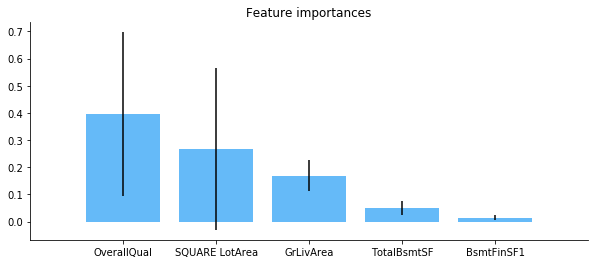

```python
print(grid_rfr.best_params_)
features_importances(grid_rfr.best_estimator_, dataset.columns, k=5)
```

```python
plot_scores(grid_rfr.best_estimator_, 'Random Forest Regressor')
```

```
Model used : Random Forest Regressor
```

|  | Training set | Validation set |
| --- | --- | --- |
| Log RMSE | 0.144054 | 0.163958 |
| Tuned Acc | 0.905069 | 0.877626 |

LASSO

```python
from sklearn.linear_model import Lasso

alphas = [0.1, 0.3, 1, 2, 3, 4.5, 6]
cv_lasso_acc = []
cv_lasso_log_rmse = []
for alpha in alphas :

    cv=cross_validate(Lasso(max_iter=20000, alpha=alpha, random_state = SEED), X_train,\
                      y_train, scoring={'tuned_acc': make_scorer(tuned_acc),\
                                        'log_rmse': make_scorer(log_rmse)}, cv=5)
    cv_lasso_acc.append(1-cv['test_tuned_acc'].mean())
    cv_lasso_log_rmse.append(cv['test_log_rmse'].mean())
```

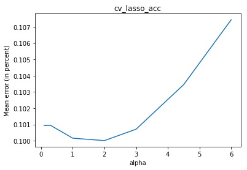

```
Text(0,0.5,'log rmse')
```

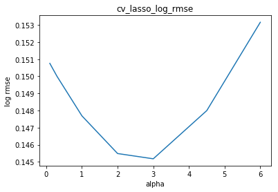

```python
cv_lasso_acc_plot = pd.Series(cv_lasso_acc, index = alphas)
cv_lasso_acc_plot.plot(title = "cv_lasso_acc")
plt.xlabel("alpha")
plt.ylabel("Mean error (in percent)")
plt.show()

cv_lasso_log_rmse_plot = pd.Series(cv_lasso_log_rmse, index = alphas)
cv_lasso_log_rmse_plot.plot(title = "cv_lasso_log_rmse")
plt.xlabel("alpha")
plt.ylabel("log rmse")
```

```python
lasso_model = Lasso(max_iter=100000, alpha=3)
```

```python
plot_scores(lasso_model,'Lasso')
```

```
Model used : Lasso
```

|  | Training set | Validation set |
| --- | --- | --- |
| Log RMSE | 0.113960 | 0.145177 |
| Tuned Acc | 0.919807 | 0.899289 |

```
Text(0.5,1,'Coefficients in Lasso')
```

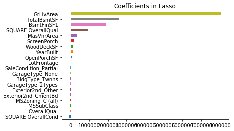

```python
coefs = pd.Series(lasso_model.coef_, index = dataset.drop('SalePrice', axis=1).columns)
imp_coef = pd.concat([coefs.sort_values().head(10), coefs.sort_values().tail(10)])
imp_coef.plot(kind = "barh")
plt.title("Coefficients in Lasso")
```

LASSO CV

```python
from sklearn.linear_model import LassoCV, LassoLarsCV

model_lassoCV = LassoCV(alphas = [2, 1, 0.1, 0.005], max_iter =200000).fit(X_train, y_train)
```

```python
plot_scores(model_lassoCV,'LassoCV')
```

```
Model used : LassoCV
```

|  | Training set | Validation set |
| --- | --- | --- |
| Log RMSE | 0.112729 | 0.149759 |
| Tuned Acc | 0.921146 | 0.899134 |

```
Text(0.5,1,'Coefficients in LassoCV')
```

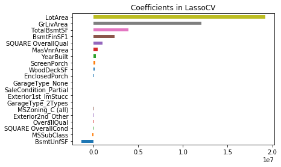

```python
coefs = pd.Series(model_lassoCV.coef_, index = dataset.drop('SalePrice', axis=1).columns)
imp_coef = pd.concat([coefs.sort_values().head(10), coefs.sort_values().tail(10)])
imp_coef.plot(kind = "barh")
plt.title("Coefficients in LassoCV")
```

Elastic net

```python
from sklearn.linear_model import ElasticNet

enet = ElasticNet(random_state = SEED)
```

```python
plot_scores(enet,'Elastic Net ')
```

```
Model used : Elastic Net
```

|  | Training set | Validation set |
| --- | --- | --- |
| Log RMSE | 0.178239 | 0.180112 |
| Tuned Acc | 0.863822 | 0.861647 |

```
Text(0.5,1,'Coefficients in Elastic Net')
```

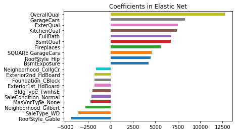

```python
coefs = pd.Series(enet.coef_, index = dataset.drop('SalePrice', axis=1).columns)
imp_coef = pd.concat([coefs.sort_values().head(10), coefs.sort_values().tail(10)])
imp_coef.plot(kind = "barh")
plt.title("Coefficients in Elastic Net")
```

Lasso lars

```python
from sklearn import linear_model
lasso_lars = linear_model.LassoLars(alpha=1)
```

```python
plot_scores(lasso_lars,'Lasso Lars ')
```

```
Model used : Lasso Lars
```

|  | Training set | Validation set |
| --- | --- | --- |
| Log RMSE | 0.108340 | 0.144104 |
| Tuned Acc | 0.924692 | 0.902651 |

```
Text(0.5,1,'Coefficients in Lasso lars')
```

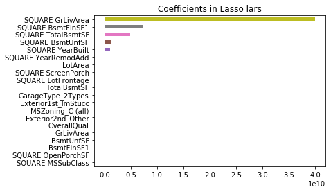

```python
coefs = pd.Series(lasso_lars.coef_, index = dataset.drop('SalePrice', axis=1).columns)
imp_coef = pd.concat([coefs.sort_values().head(10), coefs.sort_values().tail(10)])
imp_coef.plot(kind = "barh")
plt.title("Coefficients in Lasso lars")
```

#### Ridge

```python
from sklearn.linear_model import Ridge

ridge = Ridge(alpha=0.001)
```

```python
plot_scores(ridge, 'Ridge')
```

```
Model used : Ridge
```

|  | Training set | Validation set |
| --- | --- | --- |
| Log RMSE | 0.116624 | 0.151985 |
| Tuned Acc | 0.918465 | 0.896112 |

### 3. Performance Evaluation

```python
import seaborn as sns
def compute_score_cross(name,liste_reg) :
    # Returns a list of score with the given regressors

    liste_scores = []

    for clf in liste_reg :


        clf_score = cross_validate(clf, X_train, y_train, scoring={'log_rmse': make_scorer(log_rmse), \
                                                           'tuned_acc': make_scorer(tuned_acc),                                                }, cv=5)

        if name == 'log_rmse' :

            score = clf_score['test_log_rmse'].mean()

        elif name=='tuned_acc' :

            score = clf_score['test_tuned_acc'].mean()
        else :
            print('Error name')

        liste_scores.append(score)

    return liste_scores
```

```python
liste_reg = [reg,grid_rfr.best_estimator_, lasso_model, model_lassoCV,enet,\
           ridge]
```

```python
liste_scores_log_msre = compute_score_cross('log_rmse',liste_reg)
```

```python
liste_scores_tuned_acc = compute_score_cross('tuned_acc',liste_reg)
```

```python
liste_name = ['Linear Regression','Random Forest Regressor','Lasso',\
             'Lasso CV','Elastic Net','Ridge']
```

```python
def plot_scores_all(  liste_score, liste_name, score_name) :

    score_dic = {}
    score_dic['Score'] = liste_score
    score_class_df = pd.DataFrame(score_dic, index =liste_name)
    score_class_df['Regressors'] = liste_name

    sns.barplot(x='Score', y='Regressors', data=score_class_df, color="b")

    plt.xlabel(score_name)
    plt.title('Comparison of score on validation set')
    plt.show()
```

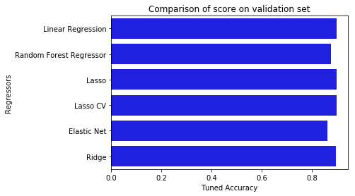

```python
plot_scores_all(  liste_scores_tuned_acc,liste_name, 'Tuned Accuracy')
```

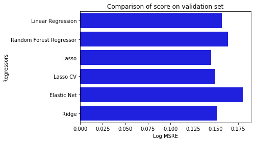

```python
plot_scores_all(  liste_scores_log_msre, liste_name, 'Log MSRE')
```

```python
print('Score for Lasso Lars : {}'.format(liste_scores_log_msre[2]))
```

[output not shown]

#### Final prediction

```python
# Final prediction on the test with the best model

y_predict = lasso_model.fit(X_train,y_train).predict(X_test)

final_score_rmse = log_rmse(y_predict, y_test)
final_score_acc = tuned_acc(y_predict, y_test)

print('Final score on test set \nLog RMSE : {}\nTuned Accuracy : {}'.format(final_score_rmse,\
                                                                               final_score_acc))
```

```
Final score on test set
Log RMSE : 0.1340906556347889
Tuned Accuracy : 0.9018455167157401
```

[output not shown]

[figure not shown]

```python
coefs = pd.Series(lasso_model.coef_, index = dataset.drop('SalePrice', axis=1).columns)
imp_coef = pd.concat([coefs.sort_values().head(10), coefs.sort_values().tail(10)])
imp_coef.plot(kind = "barh",color='b')
plt.title("Coefficients in Lasso lars")
```